# Que paso con las exportaciones del Atlántico en 2023

Autor/a

David A Sanchez Polo

Fecha de publicación

El interés y la relevancia de las exportaciones colombianas han sido constantes tanto a nivel nacional como internacional, marcando un punto de inflexión en la economía del país. A través del tiempo se ha transformado el panorama exportador colombiano, influenciado por una serie de factores que abarcadesde políticas gubernamentales hasta las fluctuantes corrientes del comercio mundial.

Al explorar las razones detrás del crecimiento en las exportaciones del departamento del Atlántico, es pertinente enfocarse en la diversificación exportadora. Se ha argumentado con frecuencia que el crecimiento económico no depende exclusivamente del volumen de las exportaciones, sino de la amplia gama de los bienes a exportar. Klinger y Lederman (2004) identificaron una relación en forma de U invertida entre el desarrollo económico y la diversificación de las exportaciones: las cuales aumentan en las etapas iniciales del desarrollo económico, pero tienden a disminuir a medida que el país alcanza y supera ciertos umbrales de ingreso medio. Este enfoque nos invita a considerar la diversificación de las exportaciones como un factor clave en el entendimiento del desempeño exportador de regiones específicas como el Atlántico, ilustrando cómo la adaptación y la innovación en la oferta exportable pueden jugar roles cruciales en el éxito económico en el contexto global actual.

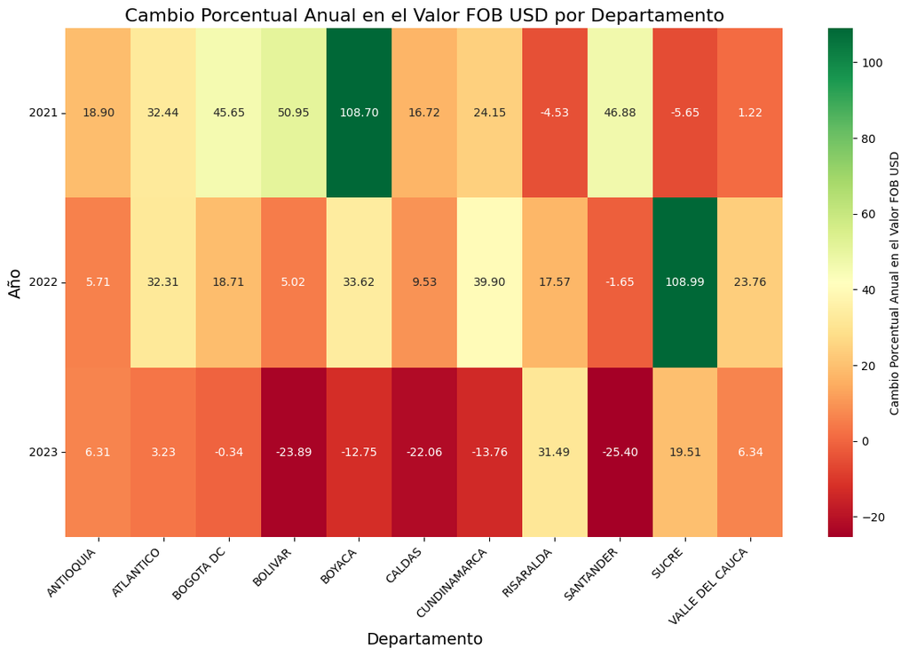

Este fenómeno se presenta como un caso sobresaliente dentro del panorama general de Colombia, que experimenta una desaceleración en sus exportaciones. La principal razón detrás de esta tendencia a la baja es la disminución de la demanda global, reflejo de un crecimiento económico mundial menos vigoroso. Según el último Informe de Perspectivas de la Economía Mundial, esta muestra signos de ralentización, con una proyección de crecimiento que disminuirá del 3.5% en 2022 al 3.0% en 2023. Este informe también anticipa un modesto aumento del comercio mundial de apenas un 0.9% para este año, cifra considerablemente inferior al promedio de 4.9% observado entre 2000 y 2019. Este pronóstico subraya no solo el impacto de la demanda global y los cambios en su composición hacia servicios domésticos, sino también las consecuencias de la apreciación del dólar y el aumento de las barreras comerciales, factores que juntos contribuyen a la desaceleración del comercio internacional.

Para poder responder al interrogante de porque el Atlantico ha tenido un crecimiento en sus exportaciones, podemos partir de varios puntos que nos permite reflexionar sobre el tema. En primer lugar, podemos darle un efoque sobre la diversificacion de las exportaciones.En este sentido, para evaluar y comprender la diversificación de las exportaciones en Colombia, es esencial utilizar herramientas analíticas que ofrezcan una perspectiva clara de cómo se distribuyen las exportaciones entre diferentes sectores o productos. Una de estas herramientas es el Índice de Herfindahl-Hirschman (HHI), un indicador ampliamente reconocido y utilizado para medir el grado de concentración o diversificación de las exportaciones (o de cualquier otro mercado). El HHI calcula la suma de los cuadrados de las cuotas de mercado de todos los competidores dentro de un mercado específico. En el contexto de las exportaciones, estas “cuotas de mercado” se refieren a la proporción que cada producto representa dentro del total de las exportaciones de un país o región.

El valor del HHI varía entre 0 y 1 (o entre 0 y 10,000 si se expresa en puntos), donde un valor cercano a 0 indica un nivel alto de diversificación (es decir, las exportaciones están repartidas equitativamente entre un gran número de productos), y un valor cercano a 1 (o 10,000 puntos) indica un alto grado de concentración (es decir, pocas exportaciones dominan el mercado). Por lo tanto, un mercado con un HHI bajo se considera competitivamente diverso y menos vulnerable a las fluctuaciones en la demanda de un solo producto o sector.

Aplicar el Índice de Herfindahl-Hirschman al análisis de las exportaciones colombianas permite identificar no solo cuán concentradas o diversificadas están las exportaciones en general, sino también cómo ha evolucionado esta diversificación a lo largo del tiempo en diferentes departamentos. Esta perspectiva es crucial para entender la resiliencia y la sostenibilidad de la economía exportadora de Colombia frente a los cambios en la demanda global y las condiciones del mercado

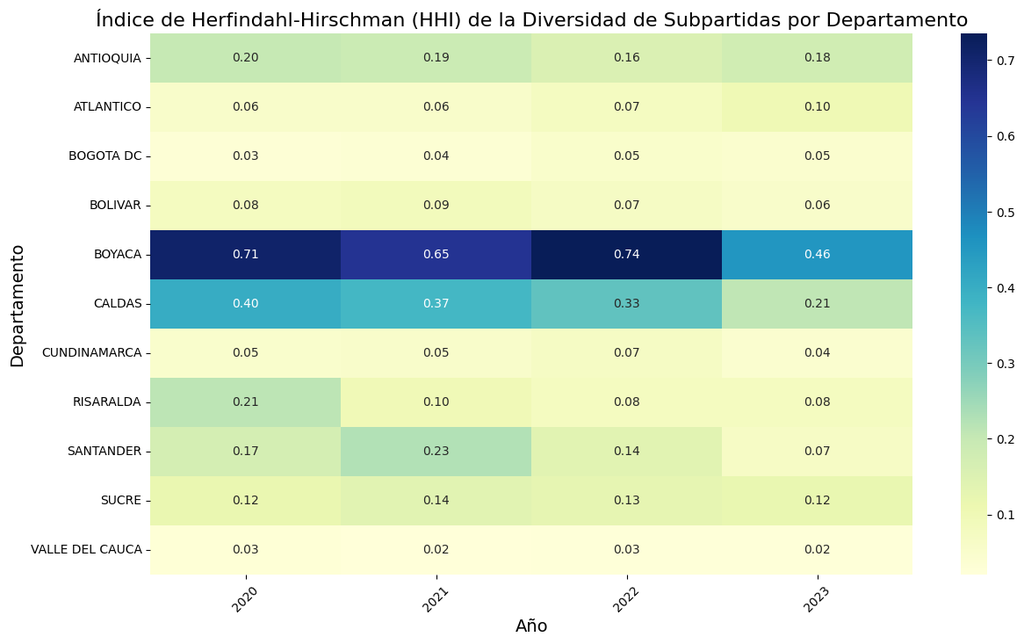

Como se puede apreciar, las economías tienden a ser más inestables en aquellos departamentos donde existe una alta concentración de exportaciones. Por ejemplo, Boyacá presenta un Índice de Herfindahl-Hirschman de 0,46, mientras que Caldas registra un índice de 0,21, indicando una concentración relativamente alta de sus exportaciones en unos pocos productos. Por otro lado, en departamentos que han experimentado un crecimiento en sus exportaciones, evidenciando una mayor diversificación, encontramos índices más bajos: Atlántico con un índice de 0,10, Antioquia con 0,18 y Valle del Cauca con un notablemente bajo índice de 0,02.

### Tendencias de las exportaciones de Colombia

| year | Descripción | Cambio % 2020 | Cambio % 2021 | Cambio % 2022 | Cambio % 2023 | Cambio % Promedio | 2020 | 2021 | 2022 | 2023 |
| --- | --- | --- | --- | --- | --- | --- | --- | --- | --- | --- |
| 43 | Industrias básicas de metales preciosos | NaN | 13.671013 | -3.280601 | 14.431027 | 8.273813 | 2.708929e+09 | 3.079267e+09 | 2.978249e+09 | 3.408041e+09 |
| 144 | Fabricación de plásticos en formas primarias | NaN | 62.039412 | -5.707971 | -31.248491 | 8.360983 | 8.431659e+08 | 1.366261e+09 | 1.288275e+09 | 8.857087e+08 |
| 67 | Fabricación de jabones y detergentes, preparad... | NaN | 9.516558 | 15.551196 | 8.038463 | 11.035406 | 5.392893e+08 | 5.906110e+08 | 6.824581e+08 | 7.373173e+08 |
| 156 | Fabricación de productos de hornos de coque | NaN | 124.408055 | 30.348408 | -42.382144 | 37.458106 | 4.189900e+08 | 9.402473e+08 | 1.225597e+09 | 7.061629e+08 |
| 31 | Fabricación de productos metálicos para uso es... | NaN | 43.100608 | 68.787231 | 28.902514 | 46.930118 | 2.247346e+08 | 3.215965e+08 | 5.428139e+08 | 6.997008e+08 |
| 95 | Fabricación de plaguicidas y otros productos q... | NaN | 17.963730 | 7.373980 | -3.261152 | 7.358853 | 3.752574e+08 | 4.426677e+08 | 4.753099e+08 | 4.598093e+08 |
| 24 | Fabricación de vehículos automotores y sus mot... | NaN | -0.201281 | 24.149891 | 38.603987 | 20.850865 | 2.525103e+08 | 2.520020e+08 | 3.128602e+08 | 4.336367e+08 |
| 123 | Extracción de hulla (carbón de piedra) | NaN | -35.433118 | 576.978776 | -13.352432 | 176.064409 | 1.135073e+08 | 7.328811e+07 | 4.961449e+08 | 4.298975e+08 |
| 122 | Confección de prendas de vestir, excepto prend... | NaN | 54.537298 | 3.196028 | -12.894721 | 14.946202 | 3.085941e+08 | 4.768929e+08 | 4.921346e+08 | 4.286752e+08 |
| 71 | Fabricación de productos farmacéuticos, sustan... | NaN | 8.303417 | 5.310299 | 6.996651 | 6.870123 | 3.490902e+08 | 3.780767e+08 | 3.981537e+08 | 4.260111e+08 |
| 63 | Elaboración de cacao, chocolate y productos de... | NaN | 25.709066 | 34.340193 | 9.901355 | 23.316871 | 2.096295e+08 | 2.635232e+08 | 3.540176e+08 | 3.890702e+08 |
| 102 | Fabricación de sustancias y productos químicos... | NaN | 30.137459 | 40.213813 | -6.461522 | 21.296583 | 2.269640e+08 | 2.953652e+08 | 4.141428e+08 | 3.873828e+08 |
| 103 | Fabricación de formas básicas de plástico | NaN | 36.678455 | 13.620905 | -6.533520 | 14.588614 | 2.473842e+08 | 3.381209e+08 | 3.841760e+08 | 3.590758e+08 |
| 126 | Fundición de metales no ferrosos | NaN | 91.685533 | 18.417903 | -13.905090 | 32.066115 | 1.781748e+08 | 3.415353e+08 | 4.044389e+08 | 3.482013e+08 |
| 108 | Otros derivados del café | NaN | 5.316529 | 34.680026 | -8.512448 | 10.494702 | 2.524748e+08 | 2.658977e+08 | 3.581111e+08 | 3.276270e+08 |

Además, observamos que en aquellos sectores del Atlántico donde se registró un cambio porcentual positivo en las exportaciones para 2023, Barranquilla ha desempeñado un papel crucial en atraer inversiones. De las 28 empresas atraídas a la región, 22 tienen una clara orientación hacia la exportación. Entre estas, sobresalen sectores clave como la industria de alimentos y bebidas, la industria química y la industria metalmecánica. Este enfoque estratégico no solo refleja el compromiso de Barranquilla con el fortalecimiento de su economía local, sino también su contribución significativa al dinamismo de las exportaciones en el Atlántico, posicionándola como un eje central en el fomento de la competitividad y la internacionalización de la economía colombiana.

| year | Descripción | 2022 | 2023 | Cambio Porcentual |
| --- | --- | --- | --- | --- |
| 120 | Fabricación de productos metálicos para uso es... | 4.943266e+08 | 6.586723e+08 | 33.246381 |
| 116 | Fabricación de plaguicidas y otros productos q... | 2.953796e+08 | 2.989791e+08 | 1.218602 |
| 132 | Fundición de metales no ferrosos | 2.392781e+08 | 1.824097e+08 | -23.766681 |
| 33 | Extracción de aceites de origen vegetal crudos | 1.543511e+08 | 1.399443e+08 | -9.333797 |
| 5 | Confección de artículos con materiales textile... | 5.277881e+07 | 5.571673e+07 | 5.566480 |
| 119 | Fabricación de productos farmacéuticos, sustan... | 4.261974e+07 | 5.363849e+07 | 25.853627 |
| 130 | Fabricación de vidrio y productos de vidrio | 3.254713e+07 | 4.921606e+07 | 51.214747 |
| 50 | Fabricación de artículos de plástico n.c.p. | 5.475747e+07 | 4.892554e+07 | -10.650469 |
| 125 | Fabricación de sustancias y productos químicos... | 4.050837e+07 | 4.631163e+07 | 14.326088 |
| 19 | Elaboración de aceites y grasas de origen vege... | 5.206102e+07 | 4.562715e+07 | -12.358318 |